# 3.1.Probability

Acknowledgments: many examples taken from the book Intuitive Biostatistics, 4th edition

Bárbara D. Bitarello

2025-10-01

## Outline

- Understand once and for all that statistics and probability are NOT intuitive
- Definitions, terminology & notations
- Next week:
  - Foundational concepts: random trials, exclusive and non-exclusive outcomes, probability rules
  - Probability distributions and sampling distributions

Motivation

## Why sample?

We almost never sample an entire population. So we can’t nail down parameters from populations.

But we can make educated guesses of parameters by making estimates from samples.

## Estimation with uncertainty

- We know that estimates will differ from parameters by chance.
- So, we must incorporate **uncertainty** in our estimation.
- How can we rigorously *quantify* this uncertainty?

## Statistics (and probability, in particular) are not intuitive

“If something has a 50% chance of happening, then 9 times out of 10 it will” — Yogi Berra

## Meaning of “intuitive”

1. “easy to understand”
2. “instinctive, or acting on what one feels to be true even without reason”

## Each row is a basketball player

Do you spot any patterns?

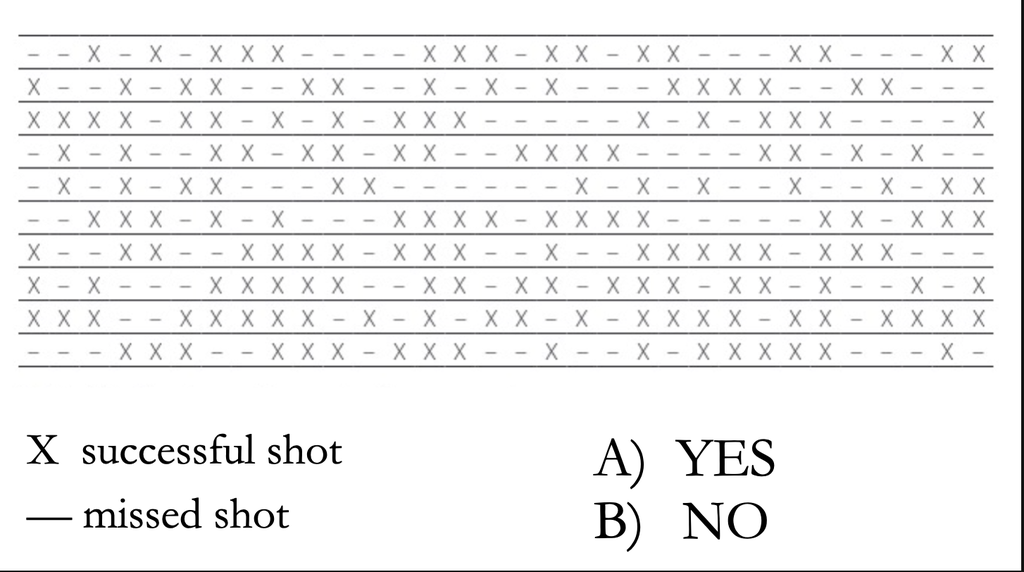

## Generalizing from a sample to a population seems to be hard-wired into our brains

[figure not shown]

Images: AFP/Getty Images/Warner Bros Records. Taken from: https://www.bbc.com/future/article/20140730-why-do-we-see-faces-in-objects

## Statistics (and probability, in particular) are not intuitive

- we see patterns in random data

Pick a range that you think has a 90% chance of containing the right answer

Don’t consult anything/anyone. The goal is to quantify your uncertainty. If you truly have no idea, you can use the broadest range that is plausible (which you can be 100% sure includes the answer) but try to narrow down your answers to a range that you are 90% sure contains the right answer.

## 99% of people are overconfident in this test

Similar studies done with experts answering questions in their own field of expertise led to similar results.

Russo, J. E., & Schoemaker, P. J. H. (1989). Decision traps. The ten barriers to brilliant decision-asking and how to overcome them. New York: Simon & Schuster.

## Statistics (and probability, in particular) are not intuitive

- we see patterns in random data
- we tend to be overconfident

## That’s all for today

[figure not shown]

From: makeameme.org